# Lab 4 - Multinomial Regression - Questions

Author

Gracielle Li

Published

March 20, 2025

Lab Goal: Predict voting frequency using demographic variables Data source: FiveThirtyEight “Why Many Americans Don’t Vote” survey Method: Multinomial logistic regression

## Data

The data for this assignment comes from an online Ipsos survey that was conducted for the FiveThirtyEight article [“Why Many Americans Don’t Vote”](https://projects.fivethirtyeight.com/non-voters-poll-2020-election/). You can read more about the survey design and respondents in the README of the [GitHub repo](https://github.com/fivethirtyeight/data/tree/master/non-voters) for the data.

Respondents were asked a variety of questions about their political beliefs, thoughts on multiple issues, and voting behavior. We will focus on using the demographic variables and someone’s party identification to understand whether a person is a probable voter.

The variables we’ll focus on were (definitions from the codebook in data set GitHub repo):

- `ppage`: Age of respondent
- `educ`: Highest educational attainment category.
- `race`: Race of respondent, census categories. Note: all categories except Hispanic were non-Hispanic.
- `gender`: Gender of respondent
- `income_cat`: Household income category of respondent
- `Q30`: Response to the question “Generally speaking, do you think of yourself as a…”
  - 1: Republican
  - 2: Democrat
  - 3: Independent
  - 4: Another party, please specify
  - 5: No preference
  - -1: No response
- `voter_category`: past voting behavior:
  - **always**: respondent voted in all or all-but-one of the elections they were eligible in
  - **sporadic**: respondent voted in at least two, but fewer than all-but-one of the elections they were eligible in
  - **rarely/never**: respondent voted in 0 or 1 of the elections they were eligible in

You can read in the data directly from the GitHub repo:

```r
library(nnet)
library(car)
library(tidyverse)
library(emmeans)
library(ggeffects)
library(knitr)
library(patchwork)
library(broom)
library(parameters)
library(easystats)
```

```r
voter_data <- read_csv("https://raw.githubusercontent.com/fivethirtyeight/data/master/non-voters/nonvoters_data.csv")
```

# Lab

- The variable `Q30` contains the respondent’s political party identification. Make a new variable that simplifies `Q30` into four categories: “Democrat”, “Republican”, “Independent”, “Other” (“Other” also includes respondents who did not answer the question).

```r
voter_data <- voter_data %>%
  mutate(pol_ident_new = case_when(
    Q30==1 ~ "Republican",
    Q30==2 ~ "Democrat",
    Q30==3 ~ "Independent",
    TRUE ~ "Other"
  ))
```

- The variable `voter_category` identifies the respondent’s past voter behavior. Relevel the variable to make rarely/never the baseline level, followed by sporadic, then always

```r
#Enter your code
voter_data <- voter_data %>%
  mutate(
    voter_category = factor(
      voter_category,
      levels = c("rarely/never", "sporadic", "always")
    )
  )
```

- Center the age variable to make the intercept more interepretable. That is, so that it reflects the log-odds for an average-aged person rather than a 0-year old person

```r
# enter code
voter_data <- voter_data %>%
  mutate(ppage = ppage - mean(ppage, na.rm = TRUE))
```

- In the [FiveThirtyEight article](https://projects.fivethirtyeight.com/non-voters-poll-2020-election/), the authors include visualizations of the relationship between the voter category and demographic variables such as race, age, education, etc. Select two demographic variables. For each variable, try to replicate the visualizations and interpret the plot to describe its relationship with voter category. Have fun with it: https://www.mikelee.co/posts/2020-02-08-recreate-fivethirtyeight-chicklet-stacked-bar-chart-in-ggplot2.

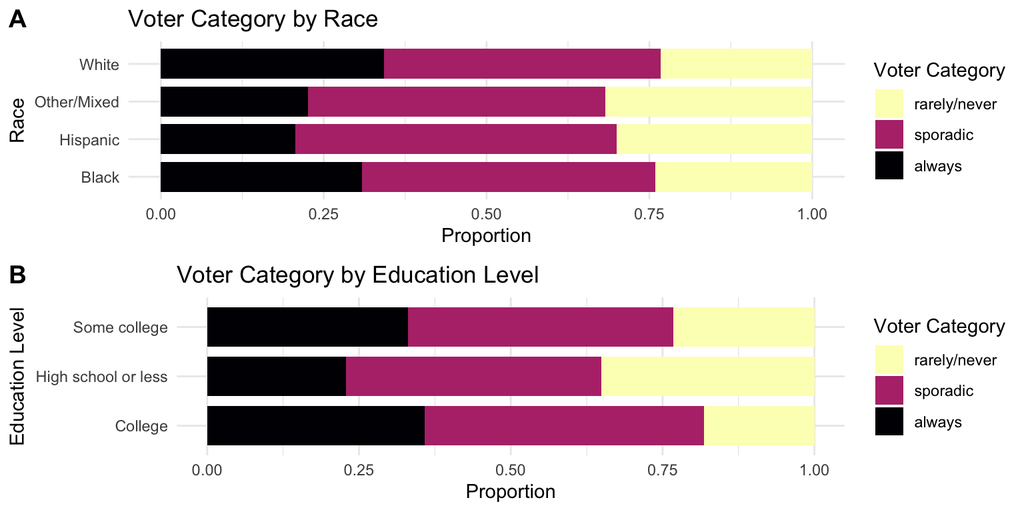

```r
# library
library(ggplot2)
library(viridis)
library(cowplot)

# Enter code
plot_race <- ggplot(voter_data, aes(y = race, fill = voter_category)) +
  geom_bar(position = "fill", width = 0.8) +
  scale_fill_viridis_d(option = "magma", direction = -1) +
  theme_minimal() +
  labs(
    title = "Voter Category by Race",
    y = "Race",
    x = "Proportion",
    fill = "Voter Category"
  )

plot_education <- ggplot(voter_data, aes(y = educ, fill = voter_category)) +
  geom_bar(position = "fill", width = 0.8) +
  scale_fill_viridis_d(option = "magma", direction = -1) +
  theme_minimal() +
  labs(
    title = "Voter Category by Education Level",
    y = "Education Level",
    x = "Proportion",
    fill = "Voter Category"
  )

plot_grid(plot_race, plot_education, labels = "AUTO", ncol = 1)
```

```r
# Enter code
plot_voter_cat <- ggplot(voter_data, aes(x = "", fill = voter_category)) +
  geom_bar(position = "fill", width = 0.8) +  # One full-width bar
  scale_fill_viridis_d(option = "magma", direction = -1) +
  theme_minimal() +
  labs(
    title = "Voter Category Distribution",
    y = "Proportion",  # Remove y-axis label
    x = NULL,
    fill = "Voter Category"
  )
```

The plots can be combined into a single plot using the patchwork package.

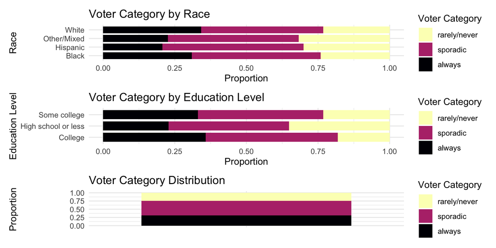

```r
library(patchwork)
# Enter code
combined_plot <- plot_race /plot_education / plot_voter_cat

print(combined_plot)
```

- Fit a model using mean-centered age, race, gender, income, and education to predict voter category. Show the code used to fit the model, but do **not** display the model output.

```r
    library(nnet)

voter_data
```

[output not shown]

```r
    #Enter code
predict_cat <- multinom(voter_category ~ ppage + race + gender + educ + income_cat, data = voter_data)
```

- *Should party identification be added to the model?*
- #Hint: Use an anova test to make the determination

```r
#Enter code

predict_cat1 <- multinom(voter_category ~ ppage + race + gender + educ + income_cat, data = voter_data)
predict_cat2 <- multinom(voter_category ~ ppage + race + gender + educ + income_cat + pol_ident_new, data = voter_data)
anova(predict_cat1, predict_cat2)
```

```
                                                      Model Resid. df
1                 ppage + race + gender + educ + income_cat     11650
2 ppage + race + gender + educ + income_cat + pol_ident_new     11644
  Resid. Dev   Test    Df LR stat. Pr(Chi)
1   11386.63           NA       NA      NA
2   11232.78 1 vs 2     6  153.844       0
```

```
> #Enter answer based on your code: yes (include), there are less residuals unaccounted for by the model
```

**Use the model you select for the remainder of the assignment**.

## LRT

- Run the full model and report overall significance of each of the terms

```r
summary(predict_cat2)
```

```
Call:
multinom(formula = voter_category ~ ppage + race + gender + educ +
    income_cat + pol_ident_new, data = voter_data)

Coefficients:
         (Intercept)      ppage raceHispanic raceOther/Mixed   raceWhite
sporadic    1.731560 0.04568619   0.04023859      -0.3324253 -0.07753808
always      1.490383 0.05820752  -0.34101920      -0.6004751  0.12720746
          genderMale educHigh school or less educSome college income_cat$40-75k
sporadic -0.09005897              -0.8532927       -0.2928893     -0.0737542388
always   -0.19218925              -1.2672114       -0.3303234     -0.0003681586
         income_cat$75-125k income_catLess than $40k pol_ident_newIndependent
sporadic         0.01249916               -0.5878096               -0.3924293
always           0.16519710               -0.6640936               -0.5623037
         pol_ident_newOther pol_ident_newRepublican
sporadic          -0.940448             -0.08380513
always            -1.400990             -0.16176773

Std. Errors:
         (Intercept)       ppage raceHispanic raceOther/Mixed raceWhite
sporadic   0.1360829 0.002324481    0.1280060       0.1590604 0.1078495
always     0.1468958 0.002565596    0.1497456       0.1853844 0.1187785
         genderMale educHigh school or less educSome college income_cat$40-75k
sporadic 0.07217151              0.09739887       0.09520334         0.1113653
always   0.07966046              0.10882778       0.10240769         0.1211677
         income_cat$75-125k income_catLess than $40k pol_ident_newIndependent
sporadic          0.1066254                0.1137398               0.09769615
always            0.1142763                0.1270306               0.10692855
         pol_ident_newOther pol_ident_newRepublican
sporadic          0.1062288               0.1027674
always            0.1312004               0.1101431

Residual Deviance: 11232.78
AIC: 11288.78
```

```r
Anova(predict_cat2)
```

```
Analysis of Deviance Table (Type II tests)

Response: voter_category
              LR Chisq Df Pr(>Chisq)
ppage           638.30  2  < 2.2e-16 ***
race             52.65  6  1.379e-09 ***
gender            6.03  2     0.0491 *
educ            154.14  4  < 2.2e-16 ***
income_cat       67.72  6  1.198e-12 ***
pol_ident_new   153.84  6  < 2.2e-16 ***
---
Signif. codes:  0 '***' 0.001 '**' 0.01 '*' 0.05 '.' 0.1 ' ' 1
```

## Marginal Effects Political Group - Emmeans

```r
#Get estimated marginal means from the model

#using
multinomial_analysis <- emmeans(predict_cat2, ~ pol_ident_new|voter_category)


coefs = contrast(regrid(multinomial_analysis, "log"),"trt.vs.ctrl1",  by="pol_ident_new")
# you can add a parameter to the above command, ref = newbaseline, if you want to change baseline

update(coefs, by = "contrast") %>%
  kable(format = "markdown", digits = 3)
```

| contrast | pol_ident_new | estimate | SE | df | t.ratio | p.value |
| --- | --- | --- | --- | --- | --- | --- |
| sporadic - (rarely/never) | Democrat | 0.961 | 0.070 | 28 | 13.722 | 0.000 |
| always - (rarely/never) | Democrat | 0.480 | 0.074 | 28 | 6.498 | 0.000 |
| sporadic - (rarely/never) | Independent | 0.591 | 0.077 | 28 | 7.643 | 0.000 |
| always - (rarely/never) | Independent | -0.049 | 0.084 | 28 | -0.590 | 0.900 |
| sporadic - (rarely/never) | Other | 0.078 | 0.087 | 28 | 0.902 | 0.747 |
| always - (rarely/never) | Other | -0.835 | 0.110 | 28 | -7.577 | 0.000 |
| sporadic - (rarely/never) | Republican | 0.883 | 0.084 | 28 | 10.469 | 0.000 |
| always - (rarely/never) | Republican | 0.327 | 0.089 | 28 | 3.672 | 0.004 |

## Marginal Effects of Education - Emmeans

```r
#Enter code
multieduc_analysis <- emmeans(predict_cat2, ~ educ|voter_category)


coefs_educ = contrast(regrid(multieduc_analysis, "log"),"trt.vs.ctrl1",  by="educ")
# you can add a parameter to the above command, ref = newbaseline, if you want to change baseline

update(coefs_educ, by = "contrast") %>%
  kable(format = "markdown", digits = 3)
```

| contrast | educ | estimate | SE | df | t.ratio | p.value |
| --- | --- | --- | --- | --- | --- | --- |
| sporadic - (rarely/never) | College | 0.986 | 0.076 | 28 | 12.904 | 0.000 |
| always - (rarely/never) | College | 0.477 | 0.080 | 28 | 5.960 | 0.000 |
| sporadic - (rarely/never) | High school or less | 0.187 | 0.069 | 28 | 2.705 | 0.031 |
| always - (rarely/never) | High school or less | -0.711 | 0.080 | 28 | -8.883 | 0.000 |
| sporadic - (rarely/never) | Some college | 0.707 | 0.074 | 28 | 9.512 | 0.000 |
| always - (rarely/never) | Some college | 0.167 | 0.079 | 28 | 2.114 | 0.112 |

- Next, plot the predicted probabilities of voter category as a function of Age and Party ID

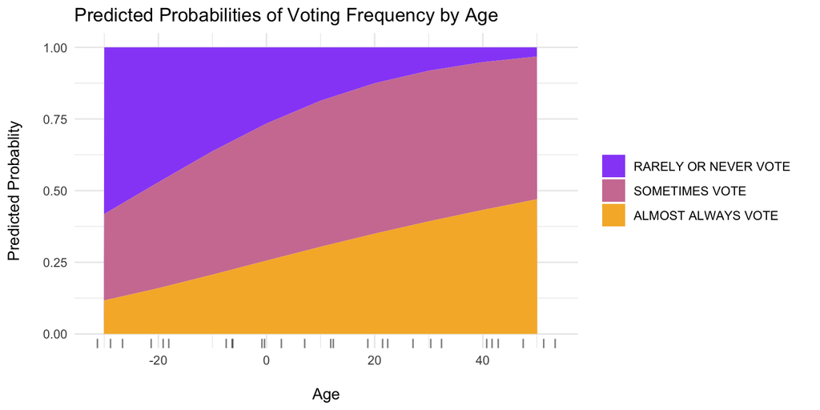

```r
mm_use <- emmeans(predict_cat2, ~ ppage + pol_ident_new|voter_category)

  ggemmeans(predict_cat2, terms = c("ppage")) %>%
      ggplot(., aes(x = x, y = predicted, fill = response.level)) +
      geom_area() +
      geom_rug(sides = "b", position = "jitter", alpha = .5) +
      labs(x = "\nAge", y = "Predicted Probablity\n", title = "Predicted Probabilities of Voting Frequency by Age") +
      scale_fill_manual(
        name = NULL,
        values = c("always" = "#F6B533", "sporadic" = "#D07EA2", "rarely/never" = "#9854F7"),
        labels = c("RARELY OR NEVER VOTE    ", "SOMETIMES VOTE    ", "ALMOST ALWAYS VOTE    "),
        breaks = c("rarely/never", "sporadic", "always")
      ) +
      theme_minimal()
```

[figure not shown]

```r
    voter_data$pol_ident_new <- as.factor(voter_data$pol_ident_new)

  df1 <- ggemmeans(predict_cat2, terms = "pol_ident_new")  # Get predicted probabilities

# bar graph
ggplot(df1, aes(x = x, y = predicted, fill = response.level)) +
  geom_bar(stat = "identity", position = "dodge") +
  labs(x = "\nEducation", y = "Predicted Probability\n",
       title = "Predicted Probabilities of Voting Frequency by Education") +
  scale_fill_manual(
    name = NULL,
    values = c("always" = "#F6B533", "sporadic" = "#D07EA2", "rarely/never" = "#9854F7"),
    labels = c("RARELY OR NEVER VOTE", "SOMETIMES VOTE", "ALMOST ALWAYS VOTE"),
    breaks = c("rarely/never", "sporadic", "always")
  ) +
  theme_minimal() +
  theme(legend.position = "top")
```

[output not shown]

Plot predicted probabilities as a function of education and voting frequency.

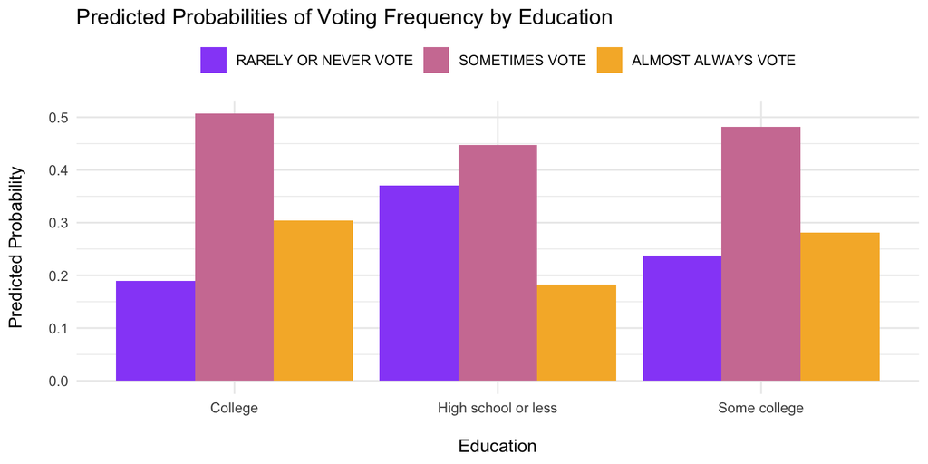

```r
voter_data$educ <- as.factor(voter_data$educ)

df <- ggemmeans(predict_cat2, terms = "educ")  # Get predicted probabilities

# bar graph
ggplot(df, aes(x = x, y = predicted, fill = response.level)) +
  geom_bar(stat = "identity", position = "dodge") +
  labs(x = "\nEducation", y = "Predicted Probability\n",
       title = "Predicted Probabilities of Voting Frequency by Education") +
  scale_fill_manual(
    name = NULL,
    values = c("always" = "#F6B533", "sporadic" = "#D07EA2", "rarely/never" = "#9854F7"),
    labels = c("RARELY OR NEVER VOTE", "SOMETIMES VOTE", "ALMOST ALWAYS VOTE"),
    breaks = c("rarely/never", "sporadic", "always")
  ) +
  theme_minimal() +
  theme(legend.position = "top")
```

[output not shown]

### Differences between political groups and voting behavior - Emmeans

```r
multi_an <- emmeans(predict_cat2, ~ pol_ident_new|voter_category)

coefs = contrast(regrid(multi_an, "log"),"trt.vs.ctrl1",  by="pol_ident_new")

update(coefs, by = "contrast") %>%
  kable(format = "markdown", digits = 3)
```

| contrast | pol_ident_new | estimate | SE | df | t.ratio | p.value |
| --- | --- | --- | --- | --- | --- | --- |
| sporadic - (rarely/never) | Democrat | 0.961 | 0.070 | 28 | 13.722 | 0.000 |
| always - (rarely/never) | Democrat | 0.480 | 0.074 | 28 | 6.498 | 0.000 |
| sporadic - (rarely/never) | Independent | 0.591 | 0.077 | 28 | 7.643 | 0.000 |
| always - (rarely/never) | Independent | -0.049 | 0.084 | 28 | -0.590 | 0.900 |
| sporadic - (rarely/never) | Other | 0.078 | 0.087 | 28 | 0.902 | 0.747 |
| always - (rarely/never) | Other | -0.835 | 0.110 | 28 | -7.577 | 0.000 |
| sporadic - (rarely/never) | Republican | 0.883 | 0.084 | 28 | 10.469 | 0.000 |
| always - (rarely/never) | Republican | 0.327 | 0.089 | 28 | 3.672 | 0.004 |

```r
# get difference between yes-no and fair-excellent
contrast(coefs, "revpairwise", by = "contrast") %>%
  kable(format = "markdown", digits = 3)
```

| contrast1 | contrast | estimate | SE | df | t.ratio | p.value |
| --- | --- | --- | --- | --- | --- | --- |
| Independent - Democrat | sporadic - (rarely/never) | -0.370 | 0.094 | 28 | -3.933 | 0.003 |
| Other - Democrat | sporadic - (rarely/never) | -0.883 | 0.103 | 28 | -8.578 | 0.000 |
| Other - Independent | sporadic - (rarely/never) | -0.513 | 0.107 | 28 | -4.807 | 0.000 |
| Republican - Democrat | sporadic - (rarely/never) | -0.078 | 0.099 | 28 | -0.787 | 0.860 |
| Republican - Independent | sporadic - (rarely/never) | 0.292 | 0.099 | 28 | 2.965 | 0.029 |
| Republican - Other | sporadic - (rarely/never) | 0.805 | 0.109 | 28 | 7.404 | 0.000 |
| Independent - Democrat | always - (rarely/never) | -0.529 | 0.101 | 28 | -5.255 | 0.000 |
| Other - Democrat | always - (rarely/never) | -1.315 | 0.125 | 28 | -10.508 | 0.000 |
| Other - Independent | always - (rarely/never) | -0.786 | 0.129 | 28 | -6.072 | 0.000 |
| Republican - Democrat | always - (rarely/never) | -0.153 | 0.104 | 28 | -1.470 | 0.468 |
| Republican - Independent | always - (rarely/never) | 0.376 | 0.104 | 28 | 3.605 | 0.006 |
| Republican - Other | always - (rarely/never) | 1.162 | 0.130 | 28 | 8.969 | 0.000 |

### Differences between education level and voting behavior - Emmeans

Last part of the assignment: Interpret the results from running the following code for your model

```r
multi_an <- emmeans(predict_cat2, ~ educ|voter_category)

coefs = contrast(regrid(multi_an, "log"),"trt.vs.ctrl1",  by="educ")

update(coefs, by = "contrast") %>%
  kable(format = "markdown", digits = 3)
```

| contrast | educ | estimate | SE | df | t.ratio | p.value |
| --- | --- | --- | --- | --- | --- | --- |
| sporadic - (rarely/never) | College | 0.986 | 0.076 | 28 | 12.904 | 0.000 |
| always - (rarely/never) | College | 0.477 | 0.080 | 28 | 5.960 | 0.000 |
| sporadic - (rarely/never) | High school or less | 0.187 | 0.069 | 28 | 2.705 | 0.031 |
| always - (rarely/never) | High school or less | -0.711 | 0.080 | 28 | -8.883 | 0.000 |
| sporadic - (rarely/never) | Some college | 0.707 | 0.074 | 28 | 9.512 | 0.000 |
| always - (rarely/never) | Some college | 0.167 | 0.079 | 28 | 2.114 | 0.112 |

```r
# get difference between yes-no and fair-excellent
contrast(coefs, "revpairwise", by = "contrast") %>%
  kable(format = "markdown", digits = 3)
```

| contrast1 | contrast | estimate | SE | df | t.ratio | p.value |
| --- | --- | --- | --- | --- | --- | --- |
| High school or less - College | sporadic - (rarely/never) | -0.799 | 0.095 | 28 | -8.416 | 0.000 |
| Some college - College | sporadic - (rarely/never) | -0.278 | 0.092 | 28 | -3.030 | 0.014 |
| Some college - High school or less | sporadic - (rarely/never) | 0.520 | 0.088 | 28 | 5.920 | 0.000 |
| High school or less - College | always - (rarely/never) | -1.188 | 0.104 | 28 | -11.394 | 0.000 |
| Some college - College | always - (rarely/never) | -0.310 | 0.097 | 28 | -3.207 | 0.009 |
| Some college - High school or less | always - (rarely/never) | 0.878 | 0.098 | 28 | 8.995 | 0.000 |